# YouTube Trending Videos Analysis

## 1. Project Overview

## 2. Import Libraries

## 3. Load the Dataset

## 4. Data Understanding

## 5. Data Cleaning & Preprocessing

## 6. Exploratory Data Analysis

### 6.1 Category Performance

### 6.2 Country Performance

### 6.3 Title Sentiment Analysis

### 6.4 Sentiment vs. Video Performance

### 6.5 Sentiment by Country

### 6.6 Sentiment by Category

### 6.7 Trending Duration Analysis

### 6.8 Engagement Rate Analysis

### 6.9 Top Trending Videos

## 7. SQL Analysis

## 8. Key Findings

## 9. Business Insights

## 10. Conclusion

# YouTube Trending Videos Analysis

## Project Overview

This project analyzes YouTube trending videos to identify patterns in video performance, audience engagement, title sentiment, publishing country, category, and trending duration.

The analysis combines Python, Pandas, data visualization, sentiment analysis, and SQL to understand what characteristics are associated with higher-performing and longer-trending YouTube videos.

### Objectives

- Analyze video performance using views, likes, and comments.
- Compare video performance across YouTube categories.
- Compare performance across publishing countries.
- Analyze sentiment in video titles.
- Examine the relationship between title sentiment and engagement.
- Analyze how long videos remain on the trending list.
- Identify highly trending and highly engaging videos.
- Use SQL and Python to perform structured data analysis.
- Generate actionable insights from the results.

### Tools & Technologies

- Python
- Pandas
- NumPy
- Matplotlib
- Seaborn
- NLTK / VADER Sentiment Analysis
- SQLite
- Jupyter Notebook

```python
import pandas as pd
import numpy as np
import matplotlib.pyplot as plt
import seaborn as sns
df = pd.read_csv(r"C:\Users\HP\Downloads\Compressed\archive\youtube.csv")
df.shape
df.head()
df.info()
df.isnull().sum()
df.describe()
```

```
<class 'pandas.core.frame.DataFrame'>
RangeIndex: 161470 entries, 0 to 161469
Data columns (total 18 columns):
 #   Column                  Non-Null Count   Dtype
---  ------                  --------------   -----
 0   index                   161470 non-null  int64
 1   video_id                161470 non-null  object
 2   trending_date           161470 non-null  object
 3   title                   161470 non-null  object
 4   channel_title           161470 non-null  object
 5   category_id             161470 non-null  int64
 6   publish_date            161470 non-null  object
 7   time_frame              161470 non-null  object
 8   published_day_of_week   161470 non-null  object
 9   publish_country         161470 non-null  object
 10  tags                    161470 non-null  object
 11  views                   161470 non-null  int64
 12  likes                   161470 non-null  int64
 13  dislikes                161470 non-null  int64
 14  comment_count           161470 non-null  int64
 15  comments_disabled       161470 non-null  bool
 16  ratings_disabled        161470 non-null  bool
 17  video_error_or_removed  161470 non-null  bool
dtypes: bool(3), int64(6), object(9)
memory usage: 18.9+ MB
```

|  | index | category_id | views | likes | dislikes | comment_count |
| --- | --- | --- | --- | --- | --- | --- |
| count | 161470.00000 | 161470.000000 | 1.614700e+05 | 1.614700e+05 | 1.614700e+05 | 1.614700e+05 |
| mean | 80734.50000 | 19.461151 | 2.419854e+06 | 6.566194e+04 | 3.490153e+03 | 7.035494e+03 |
| std | 46612.51832 | 7.432001 | 1.043749e+07 | 2.260617e+05 | 3.114779e+04 | 3.404121e+04 |
| min | 0.00000 | 1.000000 | 2.230000e+02 | 0.000000e+00 | 0.000000e+00 | 0.000000e+00 |
| 25% | 40367.25000 | 15.000000 | 1.015382e+05 | 1.975000e+03 | 8.500000e+01 | 2.790000e+02 |
| 50% | 80734.50000 | 23.000000 | 3.847395e+05 | 9.840000e+03 | 3.480000e+02 | 1.144000e+03 |
| 75% | 121101.75000 | 24.000000 | 1.339528e+06 | 4.006275e+04 | 1.350000e+03 | 4.144750e+03 |
| max | 161469.00000 | 44.000000 | 4.245389e+08 | 5.613827e+06 | 1.944971e+06 | 1.626501e+06 |

```python
df.duplicated().sum()
df["video_id"].duplicated().sum()
df["publish_country"].value_counts()
df["publish_country"].nunique()
df["category_id"].value_counts()
```

```
category_id
24    42358
10    27903
22    15960
23    13401
25    11623
17    11210
26    10442
1      9139
20     5408
28     4876
27     3873
15     2060
2      1554
19     1009
29      335
43      300
30       17
44        2
Name: count, dtype: int64
```

```python
df.duplicated().sum()
df["video_id"].duplicated().sum()
df["publish_country"].value_counts()
```

```
publish_country
US        40949
CANADA    40881
FRANCE    40724
GB        38916
Name: count, dtype: int64
```

```python
df.duplicated().sum()
df["video_id"].duplicated().sum()
```

```
np.int64(105584)
```

```python
df["trending_date"].head(20)
df["publish_date"].head(20)
df["trending_date"].sample(10, random_state=42).tolist()
```

```
['18.16.03',
 '18.08.03',
 '17.16.12',
 '18.04.06',
 '18.24.01',
 '17.04.12',
 '18.24.05',
 '18.26.02',
 '18.12.05',
 '18.01.05']
```

```python
df["trending_date"] = pd.to_datetime(
    df["trending_date"],
    format="%y.%d.%m"
)
df["publish_date"].head(10)
```

```
0    13/11/2017
1    13/11/2017
2    12/11/2017
3    13/11/2017
4    12/11/2017
5    13/11/2017
6    12/11/2017
7    12/11/2017
8    13/11/2017
9    13/11/2017
Name: publish_date, dtype: object
```

```python
df["trending_date"] = pd.to_datetime(
    df["trending_date"],
    format="%y.%d.%m"
)
df["publish_date"] = pd.to_datetime(
    df["publish_date"],
    format="%d/%m/%Y"
)

df[["trending_date", "publish_date"]].head(10)

print("Trending period:")
print(df["trending_date"].min(), "to", df["trending_date"].max())

print("\nPublishing period:")
print(df["publish_date"].min(), "to", df["publish_date"].max())
```

```
Trending period:
2017-11-14 00:00:00 to 2018-06-14 00:00:00

Publishing period:
2006-07-23 00:00:00 to 2018-06-14 00:00:00
```

```python
video_duration = df.groupby("video_id").agg(
    first_trending_date=("trending_date", "min"),
    last_trending_date=("trending_date", "max"),
    trending_days=("trending_date", "nunique")
).reset_index()
video_duration.head()
video_duration["trending_days"].describe()
video_duration.sort_values(
    "trending_days",
    ascending=False
).head(10)
```

|  | video_id | first_trending_date | last_trending_date | trending_days |
| --- | --- | --- | --- | --- |
| 0 | #NAME? | 2017-11-14 | 2018-06-14 | 205 |
| 2831 | 2z3EUY1aXdY | 2018-02-05 | 2018-03-14 | 38 |
| 10549 | BhIEIO0vaBE | 2018-02-05 | 2018-03-14 | 38 |
| 21296 | NooW_RbfdWI | 2018-02-05 | 2018-03-14 | 38 |
| 51240 | u_C4onVrr8U | 2018-04-26 | 2018-06-01 | 37 |
| 37157 | elwTgpHlty0 | 2018-02-24 | 2018-04-01 | 37 |
| 17328 | JQbjS0_ZfJ0 | 2018-02-07 | 2018-03-15 | 37 |
| 36438 | dzxFdtWmjto | 2018-02-09 | 2018-03-17 | 37 |
| 30432 | YBpdL9hSac4 | 2018-02-15 | 2018-03-23 | 37 |
| 42161 | kLpH1nSLJSs | 2018-02-15 | 2018-03-23 | 37 |

```python
video_duration.columns
video_duration.dtypes
video_duration["trending_days"].describe()
video_duration.iloc[0].to_dict()
```

```
{'video_id': '#NAME?',
 'first_trending_date': Timestamp('2017-11-14 00:00:00'),
 'last_trending_date': Timestamp('2018-06-14 00:00:00'),
 'trending_days': 205}
```

```python
video_duration["trending_days"].describe()
video_duration["trending_days"].value_counts().sort_index().head(20)
```

```
trending_days
1     33771
2     10376
3      3876
4      1637
5       968
6       793
7       749
8       469
9       397
10      323
11      366
12      323
13      339
14      251
15      175
16      126
17       92
18       93
19       84
20       75
Name: count, dtype: int64
```

```python
video_duration["trending_days"].describe()
```

```
count    55886.000000
mean         2.543195
std          3.976128
min          1.000000
25%          1.000000
50%          1.000000
75%          2.000000
max        205.000000
Name: trending_days, dtype: float64
```

```python
video_country = df.groupby("video_id")["publish_country"].first().reset_index()
video_duration = video_duration.merge(
    video_country,
    on="video_id",
    how="left"
)
country_duration = video_duration.groupby("publish_country")["trending_days"].agg(
    ["count", "mean", "median", "max"]
).sort_values("mean", ascending=False)

country_duration
```

| publish_country | count | mean | median | max |
| --- | --- | --- | --- | --- |
| GB | 2227 | 10.954648 | 9.0 | 37 |
| US | 6282 | 7.908787 | 6.0 | 205 |
| CANADA | 18002 | 1.531663 | 1.0 | 7 |
| FRANCE | 29375 | 1.377940 | 1.0 | 7 |

```python
country_duration_filtered = (
    video_duration[video_duration["trending_days"] <= 20]
    .groupby("publish_country")["trending_days"]
    .agg(["count", "mean", "median", "max"])
    .sort_values("mean", ascending=False)
)

country_duration_filtered
```

| publish_country | count | mean | median | max |
| --- | --- | --- | --- | --- |
| GB | 1951 | 8.508970 | 8.0 | 20 |
| US | 5955 | 6.757683 | 6.0 | 20 |
| CANADA | 18002 | 1.531663 | 1.0 | 7 |
| FRANCE | 29375 | 1.377940 | 1.0 | 7 |

```python
video_category = df.groupby("video_id")["category_id"].first().reset_index()

video_duration = video_duration.merge(
    video_category,
    on="video_id",
    how="left"
)
video_duration.head()
```

|  | video_id | first_trending_date | last_trending_date | trending_days | publish_country | category_id_x | category_id_y | category_id |
| --- | --- | --- | --- | --- | --- | --- | --- | --- |
| 0 | #NAME? | 2017-11-14 | 2018-06-14 | 205 | US | 15 | 15 | 15 |
| 1 | --2K8l6BWfw | 2018-03-06 | 2018-03-06 | 1 | FRANCE | 15 | 15 | 15 |
| 2 | --45ws7CEN0 | 2018-06-12 | 2018-06-12 | 1 | CANADA | 20 | 20 | 20 |
| 3 | --728h8mnDY | 2017-12-06 | 2017-12-07 | 2 | FRANCE | 26 | 26 | 26 |
| 4 | --7vNbh4UNA | 2018-04-14 | 2018-04-16 | 3 | CANADA | 25 | 25 | 25 |

```python
category_duration = video_duration.groupby("category_id")["trending_days"].agg(
    ["count", "mean", "median", "max"]
).sort_values("mean", ascending=False)

category_duration
```

| category_id | count | mean | median | max |
| --- | --- | --- | --- | --- |
| 10 | 4254 | 5.400564 | 2.0 | 37 |
| 15 | 494 | 3.971660 | 2.0 | 205 |
| 28 | 1313 | 3.162224 | 2.0 | 36 |
| 27 | 1242 | 2.790660 | 1.0 | 31 |
| 19 | 334 | 2.781437 | 2.0 | 23 |
| 1 | 2820 | 2.746454 | 1.0 | 37 |
| 26 | 3467 | 2.719931 | 1.0 | 36 |
| 23 | 4339 | 2.639087 | 2.0 | 35 |
| 20 | 1927 | 2.555786 | 1.0 | 30 |
| 24 | 15525 | 2.400709 | 1.0 | 38 |
| 22 | 7310 | 2.006019 | 1.0 | 38 |
| 44 | 1 | 2.000000 | 2.0 | 2 |
| 29 | 164 | 1.902439 | 1.0 | 36 |
| 17 | 5389 | 1.887920 | 1.0 | 38 |
| 25 | 6287 | 1.749642 | 1.0 | 36 |
| 2 | 879 | 1.657565 | 1.0 | 21 |
| 30 | 10 | 1.600000 | 1.0 | 6 |
| 43 | 131 | 1.519084 | 1.0 | 26 |

```python
category_analysis
```

| category_id | video_count | avg_views | median_views | avg_likes | avg_comments |
| --- | --- | --- | --- | --- | --- |
| 10 | 4263 | 8.224924e+06 | 1588813.0 | 215087.746837 | 17782.714296 |
| 1 | 2825 | 2.134199e+06 | 473236.0 | 45502.739249 | 5077.721742 |
| 29 | 164 | 2.080094e+06 | 74065.0 | 165666.444776 | 52396.182090 |
| 24 | 15539 | 1.601619e+06 | 378293.5 | 42029.173120 | 6173.731007 |
| 28 | 1315 | 1.438931e+06 | 502737.0 | 36040.603979 | 5363.940320 |
| 17 | 5391 | 1.136544e+06 | 264120.5 | 24703.271811 | 2987.077698 |
| 23 | 4343 | 1.095755e+06 | 507463.0 | 51232.821431 | 5077.232147 |
| 30 | 10 | 1.067571e+06 | 34760.0 | 16305.882353 | 908.588235 |
| 20 | 1928 | 1.031163e+06 | 274947.5 | 39458.788462 | 6216.750555 |
| 22 | 7316 | 9.511623e+05 | 186922.0 | 28592.012343 | 4035.977444 |
| 15 | 497 | 7.693709e+05 | 383847.0 | 21759.835437 | 2949.772330 |
| 26 | 3470 | 6.998555e+05 | 269448.0 | 26905.109845 | 3888.921758 |
| 43 | 140 | 6.781925e+05 | 590901.5 | 9332.840000 | 993.996667 |
| 2 | 881 | 6.297981e+05 | 112195.5 | 9091.481338 | 1617.563063 |
| 19 | 335 | 6.242201e+05 | 285129.0 | 10295.025768 | 1725.999009 |
| 27 | 1246 | 5.880290e+05 | 306842.0 | 24812.861348 | 2792.572941 |
| 25 | 6294 | 4.295408e+05 | 115852.0 | 7812.882905 | 2287.010755 |
| 44 | 1 | 6.470000e+03 | 6470.0 | 96.000000 | 0.000000 |

```python
import sqlite3

conn = sqlite3.connect("youtube_analysis.db")

df.to_sql(
    "youtube_trending",
    conn,
    if_exists="replace",
    index=False
)

print("Database and table created successfully!")

pd.read_sql_query(
    "SELECT COUNT(*) AS total_rows FROM youtube_trending",
    conn
)
```

```
Database and table created successfully!
```

|  | total_rows |
| --- | --- |
| 0 | 161470 |

```python
query = """
SELECT
    category_id,
    COUNT(DISTINCT video_id) AS video_count,
    ROUND(AVG(views), 2) AS avg_views,
    ROUND(AVG(likes), 2) AS avg_likes,
    ROUND(AVG(comment_count), 2) AS avg_comments
FROM youtube_trending
GROUP BY category_id
ORDER BY avg_views DESC;
"""

category_sql = pd.read_sql_query(query, conn)

category_sql
```

|  | category_id | video_count | avg_views | avg_likes | avg_comments |
| --- | --- | --- | --- | --- | --- |
| 0 | 10 | 4263 | 8224924.01 | 215087.75 | 17782.71 |
| 1 | 1 | 2825 | 2134198.73 | 45502.74 | 5077.72 |
| 2 | 29 | 164 | 2080093.77 | 165666.44 | 52396.18 |
| 3 | 24 | 15539 | 1601619.22 | 42029.17 | 6173.73 |
| 4 | 28 | 1315 | 1438931.05 | 36040.60 | 5363.94 |
| 5 | 17 | 5391 | 1136543.81 | 24703.27 | 2987.08 |
| 6 | 23 | 4343 | 1095754.93 | 51232.82 | 5077.23 |
| 7 | 30 | 10 | 1067570.82 | 16305.88 | 908.59 |
| 8 | 20 | 1928 | 1031163.22 | 39458.79 | 6216.75 |
| 9 | 22 | 7316 | 951162.34 | 28592.01 | 4035.98 |
| 10 | 15 | 497 | 769370.86 | 21759.84 | 2949.77 |
| 11 | 26 | 3470 | 699855.52 | 26905.11 | 3888.92 |
| 12 | 43 | 140 | 678192.50 | 9332.84 | 994.00 |
| 13 | 2 | 881 | 629798.10 | 9091.48 | 1617.56 |
| 14 | 19 | 335 | 624220.13 | 10295.03 | 1726.00 |
| 15 | 27 | 1246 | 588029.03 | 24812.86 | 2792.57 |
| 16 | 25 | 6294 | 429540.80 | 7812.88 | 2287.01 |
| 17 | 44 | 1 | 6470.00 | 96.00 | 0.00 |

```python
from nltk.sentiment.vader import SentimentIntensityAnalyzer

import nltk

nltk.download("vader_lexicon")
```

```
True
```

```python
sia = SentimentIntensityAnalyzer()
df["title"].iloc[0]
sia.polarity_scores(df["title"].iloc[0])
```

```
{'neg': 0.0, 'neu': 0.822, 'pos': 0.178, 'compound': 0.0772}
```

```python
sia = SentimentIntensityAnalyzer()

print(df["title"].iloc[0])
print(sia.polarity_scores(df["title"].iloc[0]))
```

```
WE WANT TO TALK ABOUT OUR MARRIAGE
{'neg': 0.0, 'neu': 0.822, 'pos': 0.178, 'compound': 0.0772}
```

```python
df["title_sentiment_score"] = df["title"].apply(
    lambda x: sia.polarity_scores(str(x))["compound"]
)

def classify_sentiment(score):
    if score >= 0.05:
        return "Positive"
    elif score <= -0.05:
        return "Negative"
    else:
        return "Neutral"

df["title_sentiment"] = df["title_sentiment_score"].apply(
    classify_sentiment
)

df["title_sentiment"].value_counts()
df[["title", "title_sentiment_score", "title_sentiment"]].head(10)
```

|  | title | title_sentiment_score | title_sentiment |
| --- | --- | --- | --- |
| 0 | WE WANT TO TALK ABOUT OUR MARRIAGE | 0.0772 | Positive |
| 1 | The Trump Presidency: Last Week Tonight with J... | 0.0000 | Neutral |
| 2 | Racist Superman \| Rudy Mancuso, King Bach & Le... | -0.6124 | Negative |
| 3 | Nickelback Lyrics: Real or Fake? | -0.4767 | Negative |
| 4 | I Dare You: GOING BALD!? | 0.0000 | Neutral |
| 5 | 2 Weeks with iPhone X | 0.0000 | Neutral |
| 6 | Roy Moore & Jeff Sessions Cold Open - SNL | 0.0000 | Neutral |
| 7 | 5 Ice Cream Gadgets put to the Test | 0.0000 | Neutral |
| 8 | The Greatest Showman \| Official Trailer 2 [HD]... | 0.6369 | Positive |
| 9 | Why the rise of the robots wonâ€™t mean the en... | 0.0000 | Neutral |

```python
sentiment_counts = df["title_sentiment"].value_counts()

sentiment_counts
sentiment_percent = (
    df["title_sentiment"]
    .value_counts(normalize=True)
    .mul(100)
    .round(2)
)

sentiment_percent
sentiment_views = df.groupby("title_sentiment").agg(
    video_count=("video_id", "nunique"),
    avg_views=("views", "mean"),
    median_views=("views", "median"),
    avg_likes=("likes", "mean"),
    avg_comments=("comment_count", "mean")
).sort_values("avg_views", ascending=False)

sentiment_views
```

| title_sentiment | video_count | avg_views | median_views | avg_likes | avg_comments |
| --- | --- | --- | --- | --- | --- |
| Negative | 7487 | 3.593707e+06 | 536937.0 | 89956.982606 | 10803.613188 |
| Positive | 8765 | 2.447044e+06 | 494560.0 | 75849.529795 | 7898.313233 |
| Neutral | 39691 | 2.101278e+06 | 316818.0 | 56015.780372 | 5766.877269 |

```python
sentiment_percent = (
    df["title_sentiment"]
    .value_counts(normalize=True)
    .mul(100)
    .round(2)
)

sentiment_percent
```

```
title_sentiment
Neutral     63.24
Positive    20.06
Negative    16.70
Name: proportion, dtype: float64
```

```python
sentiment_country = pd.crosstab(
    df["publish_country"],
    df["title_sentiment"],
    normalize="index"
).mul(100).round(2)

sentiment_country
```

| title_sentiment publish_country | Negative | Neutral | Positive |
| --- | --- | --- | --- |
| CANADA | 21.03 | 57.37 | 21.60 |
| FRANCE | 7.13 | 83.04 | 9.83 |
| GB | 19.82 | 56.96 | 23.21 |
| US | 18.92 | 55.39 | 25.69 |

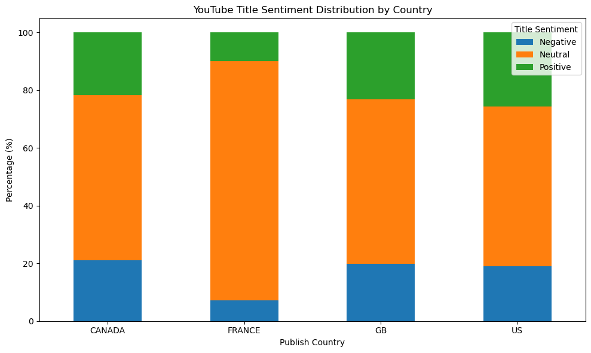

```python
import matplotlib.pyplot as plt

sentiment_country.plot(
    kind="bar",
    stacked=True,
    figsize=(10, 6)
)

plt.title("YouTube Title Sentiment Distribution by Country")
plt.xlabel("Publish Country")
plt.ylabel("Percentage (%)")
plt.legend(title="Title Sentiment")
plt.xticks(rotation=0)
plt.tight_layout()
plt.show()
```

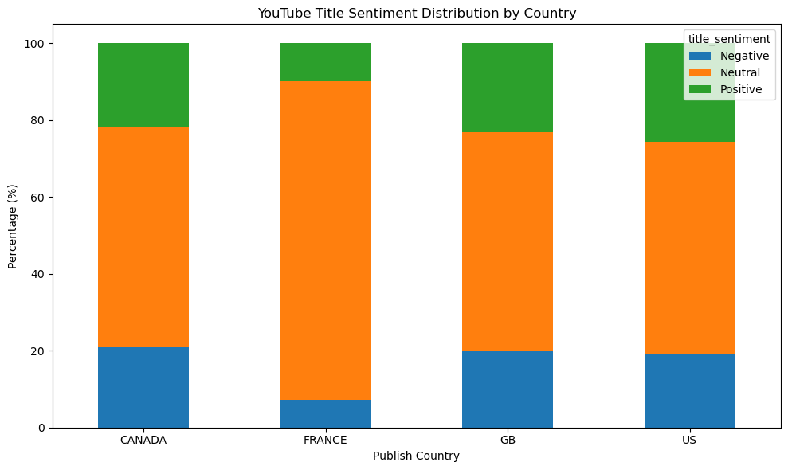

```python
plt.figure(figsize=(10, 6))

sentiment_country.plot(
    kind="bar",
    stacked=True,
    ax=plt.gca()
)

plt.title("YouTube Title Sentiment Distribution by Country")
plt.xlabel("Publish Country")
plt.ylabel("Percentage (%)")
plt.xticks(rotation=0)
plt.tight_layout()

plt.savefig("sentiment_by_country.png", dpi=300, bbox_inches="tight")
plt.show()
```

```python
video_sentiment = df.groupby("video_id")["title_sentiment"].first().reset_index()
video_duration_sentiment = video_duration.merge(
    video_sentiment,
    on="video_id",
    how="left"
)
sentiment_duration = video_duration_sentiment.groupby(
    "title_sentiment"
)["trending_days"].agg(
    ["count", "mean", "median", "max"]
).sort_values("mean", ascending=False)

sentiment_duration
```

| title_sentiment | count | mean | median | max |
| --- | --- | --- | --- | --- |
| Positive | 8745 | 3.246998 | 1.0 | 205 |
| Negative | 7470 | 3.148327 | 1.0 | 38 |
| Neutral | 39671 | 2.274105 | 1.0 | 38 |

```python
sentiment_duration_filtered = (
    video_duration_sentiment[
        video_duration_sentiment["trending_days"] <= 20
    ]
    .groupby("title_sentiment")["trending_days"]
    .agg(["count", "mean", "median", "max"])
    .sort_values("mean", ascending=False)
)

sentiment_duration_filtered
```

| title_sentiment | count | mean | median | max |
| --- | --- | --- | --- | --- |
| Positive | 8599 | 2.799628 | 1.0 | 20 |
| Negative | 7355 | 2.756492 | 1.0 | 20 |
| Neutral | 39329 | 2.047980 | 1.0 | 20 |

```python
sentiment_category = pd.crosstab(
    df["category_id"],
    df["title_sentiment"],
    normalize="index"
).mul(100).round(2)

sentiment_category
```

| title_sentiment category_id | Negative | Neutral | Positive |
| --- | --- | --- | --- |
| 1 | 24.97 | 56.00 | 19.03 |
| 2 | 12.74 | 69.63 | 17.63 |
| 10 | 14.22 | 63.34 | 22.44 |
| 15 | 14.95 | 60.53 | 24.51 |
| 17 | 11.66 | 67.70 | 20.64 |
| 19 | 10.60 | 53.72 | 35.68 |
| 20 | 19.84 | 55.36 | 24.80 |
| 22 | 10.61 | 71.95 | 17.43 |
| 23 | 18.26 | 63.63 | 18.11 |
| 24 | 19.08 | 60.23 | 20.69 |
| 25 | 24.25 | 63.02 | 12.72 |
| 26 | 11.64 | 61.89 | 26.47 |
| 27 | 21.07 | 63.90 | 15.03 |
| 28 | 11.14 | 73.79 | 15.07 |
| 29 | 31.34 | 55.82 | 12.84 |
| 30 | 5.88 | 94.12 | 0.00 |
| 43 | 0.33 | 93.67 | 6.00 |
| 44 | 0.00 | 100.00 | 0.00 |

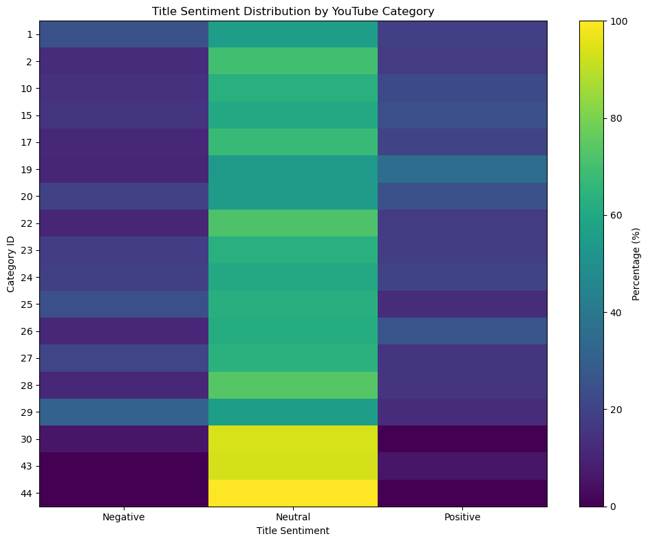

```python
import matplotlib.pyplot as plt

plt.figure(figsize=(10, 8))

plt.imshow(
    sentiment_category,
    aspect="auto"
)

plt.colorbar(label="Percentage (%)")

plt.xticks(
    range(len(sentiment_category.columns)),
    sentiment_category.columns
)

plt.yticks(
    range(len(sentiment_category.index)),
    sentiment_category.index
)

plt.xlabel("Title Sentiment")
plt.ylabel("Category ID")
plt.title("Title Sentiment Distribution by YouTube Category")

plt.tight_layout()
plt.show()
```

```python
country_duration_data.columns
```

```
Index(['video_id', 'first_trending_date', 'last_trending_date',
       'trending_days', 'publish_country_x', 'category_id_x', 'category_id_y',
       'category_id', 'publish_country_y'],
      dtype='object')
```

```python
video_country = df.groupby("video_id")["publish_country"].first().reset_index()

video_country.head()
```

|  | video_id | publish_country |
| --- | --- | --- |
| 0 | #NAME? | US |
| 1 | --2K8l6BWfw | FRANCE |
| 2 | --45ws7CEN0 | CANADA |
| 3 | --728h8mnDY | FRANCE |
| 4 | --7vNbh4UNA | CANADA |

```python
video_duration.head()
```

|  | video_id | first_trending_date | last_trending_date | trending_days | publish_country | category_id_x | category_id_y | category_id |
| --- | --- | --- | --- | --- | --- | --- | --- | --- |
| 0 | #NAME? | 2017-11-14 | 2018-06-14 | 205 | US | 15 | 15 | 15 |
| 1 | --2K8l6BWfw | 2018-03-06 | 2018-03-06 | 1 | FRANCE | 15 | 15 | 15 |
| 2 | --45ws7CEN0 | 2018-06-12 | 2018-06-12 | 1 | CANADA | 20 | 20 | 20 |
| 3 | --728h8mnDY | 2017-12-06 | 2017-12-07 | 2 | FRANCE | 26 | 26 | 26 |
| 4 | --7vNbh4UNA | 2018-04-14 | 2018-04-16 | 3 | CANADA | 25 | 25 | 25 |

```python
country_duration_data = video_duration.merge(
    video_country,
    on="video_id",
    how="left"
)

country_duration_data.head()
```

|  | video_id | first_trending_date | last_trending_date | trending_days | publish_country_x | category_id_x | category_id_y | category_id | publish_country_y |
| --- | --- | --- | --- | --- | --- | --- | --- | --- | --- |
| 0 | #NAME? | 2017-11-14 | 2018-06-14 | 205 | US | 15 | 15 | 15 | US |
| 1 | --2K8l6BWfw | 2018-03-06 | 2018-03-06 | 1 | FRANCE | 15 | 15 | 15 | FRANCE |
| 2 | --45ws7CEN0 | 2018-06-12 | 2018-06-12 | 1 | CANADA | 20 | 20 | 20 | CANADA |
| 3 | --728h8mnDY | 2017-12-06 | 2017-12-07 | 2 | FRANCE | 26 | 26 | 26 | FRANCE |
| 4 | --7vNbh4UNA | 2018-04-14 | 2018-04-16 | 3 | CANADA | 25 | 25 | 25 | CANADA |

```python
print(country_duration_data.columns.tolist())
```

```
['video_id', 'first_trending_date', 'last_trending_date', 'trending_days', 'publish_country_x', 'category_id_x', 'category_id_y', 'category_id', 'publish_country_y']
```

```python
country_duration_data[
    ["publish_country_x", "publish_country_y"]
].head(10)

country_duration_clean = country_duration_data[
    ["video_id", "trending_days", "publish_country_y"]
].copy()

country_duration_clean = country_duration_clean.rename(
    columns={"publish_country_y": "publish_country"}
)

country_duration = country_duration_clean.groupby(
    "publish_country"
)["trending_days"].agg(
    ["count", "mean", "median", "max"]
).sort_values("mean", ascending=False)

country_duration
```

| publish_country | count | mean | median | max |
| --- | --- | --- | --- | --- |
| GB | 2227 | 10.954648 | 9.0 | 37 |
| US | 6282 | 7.908787 | 6.0 | 205 |
| CANADA | 18002 | 1.531663 | 1.0 | 7 |
| FRANCE | 29375 | 1.377940 | 1.0 | 7 |

```python
country_performance = df.groupby("publish_country").agg(
    video_count=("video_id", "nunique"),
    avg_views=("views", "mean"),
    median_views=("views", "median"),
    avg_likes=("likes", "mean"),
    avg_comments=("comment_count", "mean")
).sort_values("avg_views", ascending=False)

country_performance
```

| publish_country | video_count | avg_views | median_views | avg_likes | avg_comments |
| --- | --- | --- | --- | --- | --- |
| GB | 3237 | 5.911944e+06 | 981889.0 | 134519.553500 | 13088.353145 |
| US | 6282 | 2.360785e+06 | 681861.0 | 74266.702435 | 8446.803683 |
| CANADA | 24104 | 1.147036e+06 | 371204.0 | 39582.688241 | 5042.974707 |
| FRANCE | 30182 | 4.199219e+05 | 73721.0 | 17388.863815 | 1832.452706 |

[figure not shown]

```python
plt.figure(figsize=(9, 6))

country_performance["avg_views"].sort_values().plot(
    kind="barh"
)

plt.title("Average YouTube Views by Publishing Country")
plt.xlabel("Average Views")
plt.ylabel("Publishing Country")
plt.tight_layout()
plt.show()
```

[figure not shown]

```python
country_views_millions = (
    country_performance["avg_views"] / 1_000_000
).sort_values()

plt.figure(figsize=(9, 6))

country_views_millions.plot(kind="barh")

plt.title("Average YouTube Views by Publishing Country")
plt.xlabel("Average Views (Millions)")
plt.ylabel("Publishing Country")
plt.tight_layout()
plt.show()
```

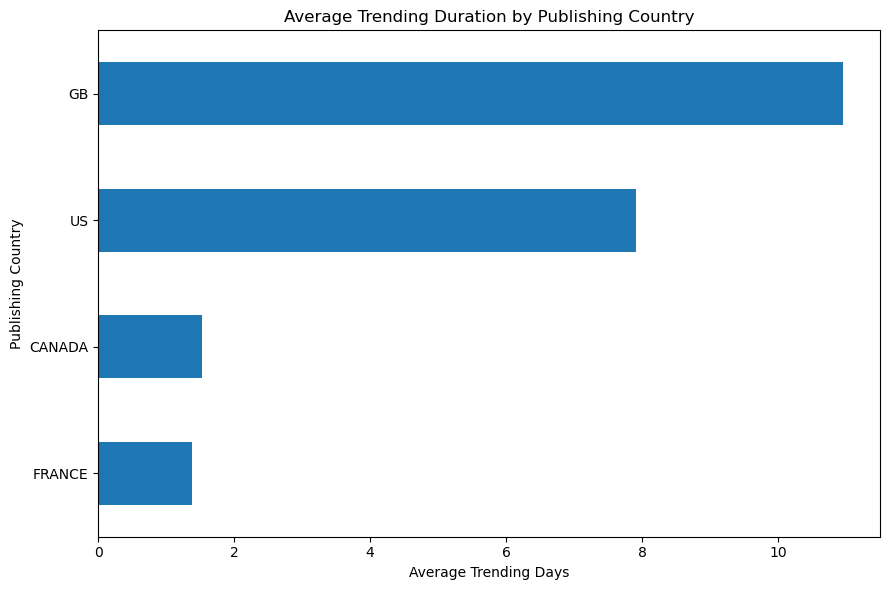

```python
plt.figure(figsize=(9, 6))

country_duration["mean"].sort_values().plot(
    kind="barh"
)

plt.title("Average Trending Duration by Publishing Country")
plt.xlabel("Average Trending Days")
plt.ylabel("Publishing Country")
plt.tight_layout()
plt.show()
```

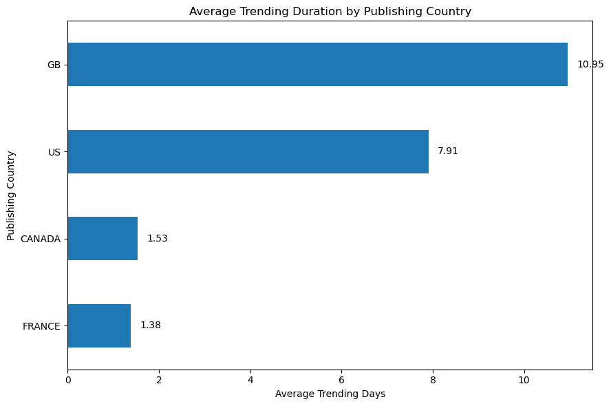

```python
plt.figure(figsize=(9, 6))

duration_sorted = country_duration["mean"].sort_values()

ax = duration_sorted.plot(kind="barh")

for i, value in enumerate(duration_sorted):
    ax.text(
        value + 0.2,
        i,
        f"{value:.2f}",
        va="center"
    )

plt.title("Average Trending Duration by Publishing Country")
plt.xlabel("Average Trending Days")
plt.ylabel("Publishing Country")
plt.tight_layout()
plt.show()
```

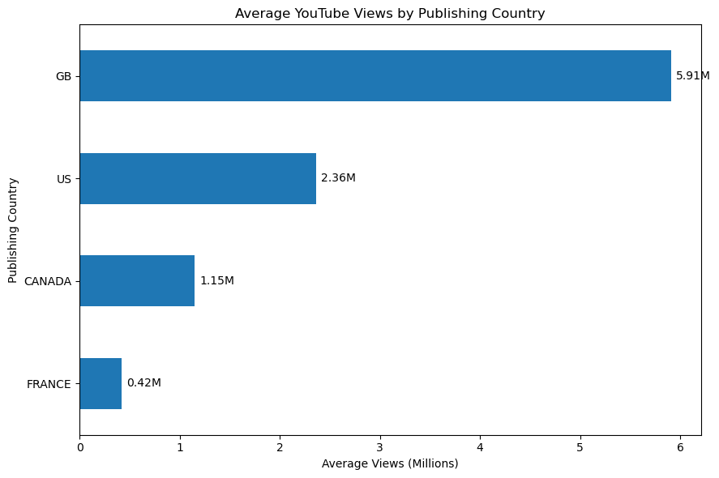

```python
country_views_millions = (
    country_performance["avg_views"] / 1_000_000
).sort_values()

plt.figure(figsize=(9, 6))

ax = country_views_millions.plot(kind="barh")

for i, value in enumerate(country_views_millions):
    ax.text(
        value + 0.05,
        i,
        f"{value:.2f}M",
        va="center"
    )

plt.title("Average YouTube Views by Publishing Country")
plt.xlabel("Average Views (Millions)")
plt.ylabel("Publishing Country")
plt.tight_layout()
plt.show()
```

```python
# Get top 20 longest-trending videos
top_duration = (
    video_duration[
        ["video_id", "first_trending_date", "last_trending_date", "trending_days"]
    ]
    .sort_values("trending_days", ascending=False)
    .head(20)
    .copy()
)

# Get one clean record per video
video_details = (
    df.groupby("video_id")
    .agg(
        title=("title", "first"),
        channel_title=("channel_title", "first"),
        category_id=("category_id", "first"),
        publish_country=("publish_country", "first"),
        views=("views", "max"),
        likes=("likes", "max")
    )
    .reset_index()
)

# Merge the clean tables
top_trending_videos = top_duration.merge(
    video_details,
    on="video_id",
    how="left"
)

top_trending_videos
```

|  | video_id | first_trending_date | last_trending_date | trending_days | title | channel_title | category_id | publish_country | views | likes |
| --- | --- | --- | --- | --- | --- | --- | --- | --- | --- | --- |
| 0 | #NAME? | 2017-11-14 | 2018-06-14 | 205 | Animal Adventure Park Giraffe Cam | Animal Adventure Park | 15 | US | 87264467 | 815369 |
| 1 | 2z3EUY1aXdY | 2018-02-05 | 2018-03-14 | 38 | Justin Timberlake’s FULL Pepsi Super Bowl LI... | NFL | 17 | US | 14251760 | 169320 |
| 2 | BhIEIO0vaBE | 2018-02-05 | 2018-03-14 | 38 | To Our Daughter | Kylie Jenner | 22 | US | 62338362 | 0 |
| 3 | NooW_RbfdWI | 2018-02-05 | 2018-03-14 | 38 | Jurassic World: Fallen Kingdom - Official Trai... | Universal Pictures | 24 | US | 24293173 | 275268 |
| 4 | u_C4onVrr8U | 2018-04-26 | 2018-06-01 | 37 | Miguel - Come Through and Chill (Official Vide... | MiguelVEVO | 10 | US | 9657370 | 152765 |
| 5 | elwTgpHlty0 | 2018-02-24 | 2018-04-01 | 37 | [OFFICIAL VIDEO] HAVANA - PENTATONIX | PTXofficial | 10 | US | 15931393 | 510639 |
| 6 | JQbjS0_ZfJ0 | 2018-02-07 | 2018-03-15 | 37 | Kendrick Lamar, SZA - All The Stars | KendrickLamarVEVO | 10 | US | 69257303 | 1021380 |
| 7 | dzxFdtWmjto | 2018-02-09 | 2018-03-17 | 37 | VENOM - Official Teaser Trailer (HD) | Sony Pictures Entertainment | 24 | US | 16416756 | 219113 |
| 8 | YBpdL9hSac4 | 2018-02-15 | 2018-03-23 | 37 | Incredibles 2 - Olympics Sneak Peek | Disney•Pixar | 1 | US | 42560014 | 461135 |
| 9 | kLpH1nSLJSs | 2018-02-15 | 2018-03-23 | 37 | Bad Bunny - Amorfoda \| Video Oficial | Bad Bunny | 10 | GB | 328860380 | 3823879 |
| 10 | ABLsSWE06q4 | 2018-02-09 | 2018-03-17 | 37 | Whethan, Dua Lipa - High (Audio) | FiftyShadesVEVO | 10 | GB | 7285185 | 108466 |
| 11 | AHwZBYCwxPY | 2018-03-01 | 2018-04-06 | 37 | Tory Lanez Kills The 5 Fingers of Death (9 Min... | Sway's Universe | 24 | GB | 1285088 | 38312 |
| 12 | tGRzz0oqgUE | 2018-02-23 | 2018-03-31 | 37 | Janelle Monáe – Make Me Feel [Official Musi... | Janelle Monáe | 10 | US | 8585663 | 150947 |
| 13 | V5cOvyDpWfM | 2018-02-19 | 2018-03-27 | 37 | Fergie Performs The U.S. National Anthem / 201... | MLG Highlights | 17 | US | 22975455 | 69172 |
| 14 | h-6fIyaVmDM | 2018-02-07 | 2018-03-15 | 37 | Pawn Stars: Dana White Wants Rick's 1600s Japa... | HISTORY | 24 | GB | 4180960 | 26374 |
| 15 | _I_D_8Z4sJE | 2018-03-02 | 2018-04-07 | 37 | Nicky Jam x J. Balvin - X (EQUIS) \| Video Oficial | NickyJamTV | 10 | GB | 424538912 | 2818771 |
| 16 | T3hXC5yNZOc | 2018-03-01 | 2018-04-06 | 37 | Iggy Azalea - Savior ft. Quavo | iggyazaleamusicVEVO | 10 | US | 9251221 | 212864 |
| 17 | Q17z9a03YaM | 2018-02-21 | 2018-03-29 | 37 | Rich Brian - Cold (Official Music Video) | 88rising | 24 | GB | 7536395 | 205275 |
| 18 | BQ31l1gPGKM | 2018-02-26 | 2018-04-03 | 37 | J. Balvin - Ahora | jbalvinVEVO | 10 | US | 74572317 | 610489 |
| 19 | kton-qrKNLc | 2018-03-02 | 2018-04-07 | 37 | Meghan Trainor - No Excuses | MeghanTrainorVEVO | 10 | US | 32324578 | 455891 |

```python
top_trending_videos[
    [
        "video_id",
        "title",
        "channel_title",
        "category_id",
        "publish_country",
        "first_trending_date",
        "last_trending_date",
        "trending_days",
        "views",
        "likes"
    ]
]
```

|  | video_id | title | channel_title | category_id | publish_country | first_trending_date | last_trending_date | trending_days | views | likes |
| --- | --- | --- | --- | --- | --- | --- | --- | --- | --- | --- |
| 0 | #NAME? | Animal Adventure Park Giraffe Cam | Animal Adventure Park | 15 | US | 2017-11-14 | 2018-06-14 | 205 | 87264467 | 815369 |
| 1 | 2z3EUY1aXdY | Justin Timberlake’s FULL Pepsi Super Bowl LI... | NFL | 17 | US | 2018-02-05 | 2018-03-14 | 38 | 14251760 | 169320 |
| 2 | BhIEIO0vaBE | To Our Daughter | Kylie Jenner | 22 | US | 2018-02-05 | 2018-03-14 | 38 | 62338362 | 0 |
| 3 | NooW_RbfdWI | Jurassic World: Fallen Kingdom - Official Trai... | Universal Pictures | 24 | US | 2018-02-05 | 2018-03-14 | 38 | 24293173 | 275268 |
| 4 | u_C4onVrr8U | Miguel - Come Through and Chill (Official Vide... | MiguelVEVO | 10 | US | 2018-04-26 | 2018-06-01 | 37 | 9657370 | 152765 |
| 5 | elwTgpHlty0 | [OFFICIAL VIDEO] HAVANA - PENTATONIX | PTXofficial | 10 | US | 2018-02-24 | 2018-04-01 | 37 | 15931393 | 510639 |
| 6 | JQbjS0_ZfJ0 | Kendrick Lamar, SZA - All The Stars | KendrickLamarVEVO | 10 | US | 2018-02-07 | 2018-03-15 | 37 | 69257303 | 1021380 |
| 7 | dzxFdtWmjto | VENOM - Official Teaser Trailer (HD) | Sony Pictures Entertainment | 24 | US | 2018-02-09 | 2018-03-17 | 37 | 16416756 | 219113 |
| 8 | YBpdL9hSac4 | Incredibles 2 - Olympics Sneak Peek | Disney•Pixar | 1 | US | 2018-02-15 | 2018-03-23 | 37 | 42560014 | 461135 |
| 9 | kLpH1nSLJSs | Bad Bunny - Amorfoda \| Video Oficial | Bad Bunny | 10 | GB | 2018-02-15 | 2018-03-23 | 37 | 328860380 | 3823879 |
| 10 | ABLsSWE06q4 | Whethan, Dua Lipa - High (Audio) | FiftyShadesVEVO | 10 | GB | 2018-02-09 | 2018-03-17 | 37 | 7285185 | 108466 |
| 11 | AHwZBYCwxPY | Tory Lanez Kills The 5 Fingers of Death (9 Min... | Sway's Universe | 24 | GB | 2018-03-01 | 2018-04-06 | 37 | 1285088 | 38312 |
| 12 | tGRzz0oqgUE | Janelle Monáe – Make Me Feel [Official Musi... | Janelle Monáe | 10 | US | 2018-02-23 | 2018-03-31 | 37 | 8585663 | 150947 |
| 13 | V5cOvyDpWfM | Fergie Performs The U.S. National Anthem / 201... | MLG Highlights | 17 | US | 2018-02-19 | 2018-03-27 | 37 | 22975455 | 69172 |
| 14 | h-6fIyaVmDM | Pawn Stars: Dana White Wants Rick's 1600s Japa... | HISTORY | 24 | GB | 2018-02-07 | 2018-03-15 | 37 | 4180960 | 26374 |
| 15 | _I_D_8Z4sJE | Nicky Jam x J. Balvin - X (EQUIS) \| Video Oficial | NickyJamTV | 10 | GB | 2018-03-02 | 2018-04-07 | 37 | 424538912 | 2818771 |
| 16 | T3hXC5yNZOc | Iggy Azalea - Savior ft. Quavo | iggyazaleamusicVEVO | 10 | US | 2018-03-01 | 2018-04-06 | 37 | 9251221 | 212864 |
| 17 | Q17z9a03YaM | Rich Brian - Cold (Official Music Video) | 88rising | 24 | GB | 2018-02-21 | 2018-03-29 | 37 | 7536395 | 205275 |
| 18 | BQ31l1gPGKM | J. Balvin - Ahora | jbalvinVEVO | 10 | US | 2018-02-26 | 2018-04-03 | 37 | 74572317 | 610489 |
| 19 | kton-qrKNLc | Meghan Trainor - No Excuses | MeghanTrainorVEVO | 10 | US | 2018-03-02 | 2018-04-07 | 37 | 32324578 | 455891 |

```python
top_valid_trending = top_trending_videos[
    top_trending_videos["video_id"] != "#NAME?"
].copy()

top_valid_trending = top_valid_trending.head(15)

top_valid_trending[
    [
        "video_id",
        "title",
        "channel_title",
        "category_id",
        "publish_country",
        "trending_days",
        "views",
        "likes"
    ]
]
```

|  | video_id | title | channel_title | category_id | publish_country | trending_days | views | likes |
| --- | --- | --- | --- | --- | --- | --- | --- | --- |
| 1 | 2z3EUY1aXdY | Justin Timberlake’s FULL Pepsi Super Bowl LI... | NFL | 17 | US | 38 | 14251760 | 169320 |
| 2 | BhIEIO0vaBE | To Our Daughter | Kylie Jenner | 22 | US | 38 | 62338362 | 0 |
| 3 | NooW_RbfdWI | Jurassic World: Fallen Kingdom - Official Trai... | Universal Pictures | 24 | US | 38 | 24293173 | 275268 |
| 4 | u_C4onVrr8U | Miguel - Come Through and Chill (Official Vide... | MiguelVEVO | 10 | US | 37 | 9657370 | 152765 |
| 5 | elwTgpHlty0 | [OFFICIAL VIDEO] HAVANA - PENTATONIX | PTXofficial | 10 | US | 37 | 15931393 | 510639 |
| 6 | JQbjS0_ZfJ0 | Kendrick Lamar, SZA - All The Stars | KendrickLamarVEVO | 10 | US | 37 | 69257303 | 1021380 |
| 7 | dzxFdtWmjto | VENOM - Official Teaser Trailer (HD) | Sony Pictures Entertainment | 24 | US | 37 | 16416756 | 219113 |
| 8 | YBpdL9hSac4 | Incredibles 2 - Olympics Sneak Peek | Disney•Pixar | 1 | US | 37 | 42560014 | 461135 |
| 9 | kLpH1nSLJSs | Bad Bunny - Amorfoda \| Video Oficial | Bad Bunny | 10 | GB | 37 | 328860380 | 3823879 |
| 10 | ABLsSWE06q4 | Whethan, Dua Lipa - High (Audio) | FiftyShadesVEVO | 10 | GB | 37 | 7285185 | 108466 |
| 11 | AHwZBYCwxPY | Tory Lanez Kills The 5 Fingers of Death (9 Min... | Sway's Universe | 24 | GB | 37 | 1285088 | 38312 |
| 12 | tGRzz0oqgUE | Janelle Monáe – Make Me Feel [Official Musi... | Janelle Monáe | 10 | US | 37 | 8585663 | 150947 |
| 13 | V5cOvyDpWfM | Fergie Performs The U.S. National Anthem / 201... | MLG Highlights | 17 | US | 37 | 22975455 | 69172 |
| 14 | h-6fIyaVmDM | Pawn Stars: Dana White Wants Rick's 1600s Japa... | HISTORY | 24 | GB | 37 | 4180960 | 26374 |
| 15 | _I_D_8Z4sJE | Nicky Jam x J. Balvin - X (EQUIS) \| Video Oficial | NickyJamTV | 10 | GB | 37 | 424538912 | 2818771 |

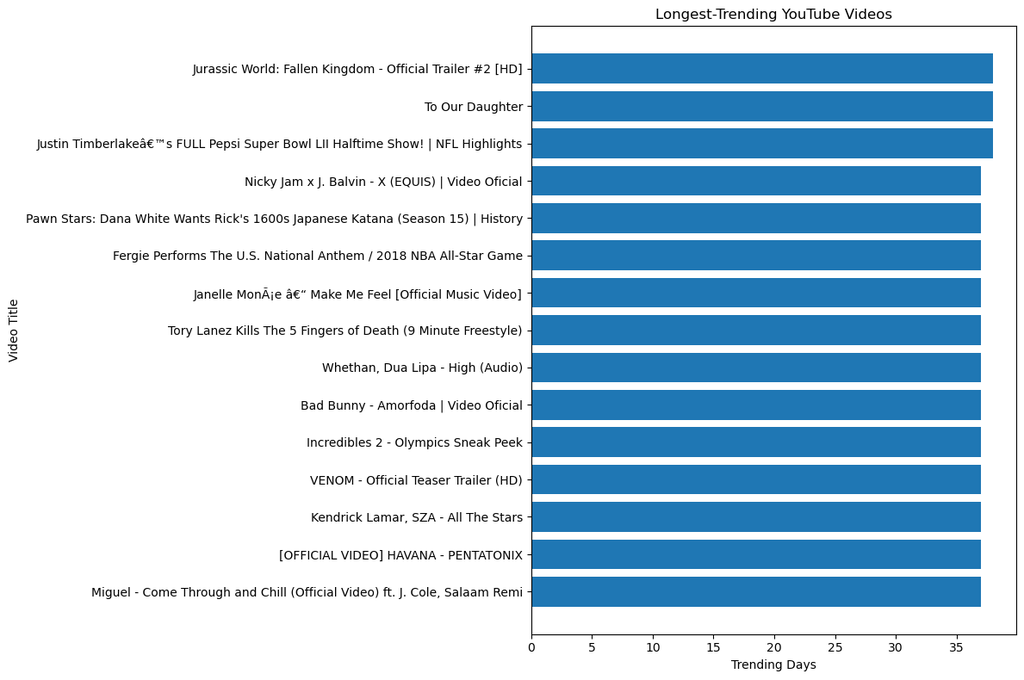

```python
plt.figure(figsize=(12, 8))

plot_data = top_valid_trending.sort_values(
    "trending_days",
    ascending=True
)

plt.barh(
    plot_data["title"],
    plot_data["trending_days"]
)

plt.xlabel("Trending Days")
plt.ylabel("Video Title")
plt.title("Longest-Trending YouTube Videos")

plt.tight_layout()
plt.show()
```

```python
top_category_counts = (
    top_valid_trending["category_id"]
    .value_counts()
)

top_category_counts
```

```
category_id
10    7
24    4
17    2
22    1
1     1
Name: count, dtype: int64
```

```python
top_country_counts = (
    top_valid_trending["publish_country"]
    .value_counts()
)

top_country_counts
```

```
publish_country
US    10
GB     5
Name: count, dtype: int64
```

```python
top_category_counts
```

```
category_id
10    7
24    4
17    2
22    1
1     1
Name: count, dtype: int64
```

```python
query = """
SELECT
    category_id,
    COUNT(DISTINCT video_id) AS video_count,
    ROUND(AVG(views), 2) AS avg_views,
    ROUND(AVG(likes), 2) AS avg_likes,
    ROUND(AVG(comment_count), 2) AS avg_comments
FROM youtube_trending
GROUP BY category_id
ORDER BY avg_views DESC;
"""

result = pd.read_sql_query(query, conn)
result
```

|  | category_id | video_count | avg_views | avg_likes | avg_comments |
| --- | --- | --- | --- | --- | --- |
| 0 | 10 | 4263 | 8224924.01 | 215087.75 | 17782.71 |
| 1 | 1 | 2825 | 2134198.73 | 45502.74 | 5077.72 |
| 2 | 29 | 164 | 2080093.77 | 165666.44 | 52396.18 |
| 3 | 24 | 15539 | 1601619.22 | 42029.17 | 6173.73 |
| 4 | 28 | 1315 | 1438931.05 | 36040.60 | 5363.94 |
| 5 | 17 | 5391 | 1136543.81 | 24703.27 | 2987.08 |
| 6 | 23 | 4343 | 1095754.93 | 51232.82 | 5077.23 |
| 7 | 30 | 10 | 1067570.82 | 16305.88 | 908.59 |
| 8 | 20 | 1928 | 1031163.22 | 39458.79 | 6216.75 |
| 9 | 22 | 7316 | 951162.34 | 28592.01 | 4035.98 |
| 10 | 15 | 497 | 769370.86 | 21759.84 | 2949.77 |
| 11 | 26 | 3470 | 699855.52 | 26905.11 | 3888.92 |
| 12 | 43 | 140 | 678192.50 | 9332.84 | 994.00 |
| 13 | 2 | 881 | 629798.10 | 9091.48 | 1617.56 |
| 14 | 19 | 335 | 624220.13 | 10295.03 | 1726.00 |
| 15 | 27 | 1246 | 588029.03 | 24812.86 | 2792.57 |
| 16 | 25 | 6294 | 429540.80 | 7812.88 | 2287.01 |
| 17 | 44 | 1 | 6470.00 | 96.00 | 0.00 |

```python
import sqlite3
import pandas as pd

conn = sqlite3.connect("youtube_analysis.db")
```

```python
pd.read_sql_query(
    "SELECT COUNT(*) AS total_rows FROM youtube_trending",
    conn
)
```

|  | total_rows |
| --- | --- |
| 0 | 161470 |

```python
query = """
SELECT
    category_id,
    COUNT(DISTINCT video_id) AS video_count,
    ROUND(AVG(views), 2) AS avg_views,
    ROUND(AVG(likes), 2) AS avg_likes,
    ROUND(AVG(comment_count), 2) AS avg_comments
FROM youtube_trending
GROUP BY category_id
ORDER BY avg_views DESC;
"""

category_sql = pd.read_sql_query(query, conn)

category_sql
```

|  | category_id | video_count | avg_views | avg_likes | avg_comments |
| --- | --- | --- | --- | --- | --- |
| 0 | 10 | 4263 | 8224924.01 | 215087.75 | 17782.71 |
| 1 | 1 | 2825 | 2134198.73 | 45502.74 | 5077.72 |
| 2 | 29 | 164 | 2080093.77 | 165666.44 | 52396.18 |
| 3 | 24 | 15539 | 1601619.22 | 42029.17 | 6173.73 |
| 4 | 28 | 1315 | 1438931.05 | 36040.60 | 5363.94 |
| 5 | 17 | 5391 | 1136543.81 | 24703.27 | 2987.08 |
| 6 | 23 | 4343 | 1095754.93 | 51232.82 | 5077.23 |
| 7 | 30 | 10 | 1067570.82 | 16305.88 | 908.59 |
| 8 | 20 | 1928 | 1031163.22 | 39458.79 | 6216.75 |
| 9 | 22 | 7316 | 951162.34 | 28592.01 | 4035.98 |
| 10 | 15 | 497 | 769370.86 | 21759.84 | 2949.77 |
| 11 | 26 | 3470 | 699855.52 | 26905.11 | 3888.92 |
| 12 | 43 | 140 | 678192.50 | 9332.84 | 994.00 |
| 13 | 2 | 881 | 629798.10 | 9091.48 | 1617.56 |
| 14 | 19 | 335 | 624220.13 | 10295.03 | 1726.00 |
| 15 | 27 | 1246 | 588029.03 | 24812.86 | 2792.57 |
| 16 | 25 | 6294 | 429540.80 | 7812.88 | 2287.01 |
| 17 | 44 | 1 | 6470.00 | 96.00 | 0.00 |

```python
query = """
SELECT
    publish_country,
    COUNT(DISTINCT video_id) AS video_count,
    ROUND(AVG(views), 2) AS avg_views,
    ROUND(AVG(likes), 2) AS avg_likes,
    ROUND(AVG(comment_count), 2) AS avg_comments
FROM youtube_trending
GROUP BY publish_country
ORDER BY avg_views DESC;
"""

country_sql = pd.read_sql_query(query, conn)

country_sql
```

|  | publish_country | video_count | avg_views | avg_likes | avg_comments |
| --- | --- | --- | --- | --- | --- |
| 0 | GB | 3237 | 5911943.63 | 134519.55 | 13088.35 |
| 1 | US | 6282 | 2360784.64 | 74266.70 | 8446.80 |
| 2 | CANADA | 24104 | 1147035.91 | 39582.69 | 5042.97 |
| 3 | FRANCE | 30182 | 419921.85 | 17388.86 | 1832.45 |

```python
query = """
SELECT
    video_id,
    title,
    channel_title,
    publish_country,
    views,
    likes,
    comment_count
FROM youtube_trending
GROUP BY video_id
ORDER BY views DESC
LIMIT 10;
"""

top_videos_sql = pd.read_sql_query(query, conn)

top_videos_sql
```

|  | video_id | title | channel_title | publish_country | views | likes | comment_count |
| --- | --- | --- | --- | --- | --- | --- | --- |
| 0 | WtE011iVx1Q | Sebastián Yatra - Por Perro ft. Luis Figueroa... | SebastianYatraVEVO | GB | 47669287 | 396337 | 15955 |
| 1 | Ck4xHocysLw | Ozuna - UÌnica (Video Oficial) ðŸ» A U R A | Ozuna | GB | 42923278 | 495422 | 18091 |
| 2 | 7C2z4GqqS5E | BTS (ë°©íƒ„ì†Œë…„ë‹¨) 'FAKE LOVE' Official MV | ibighit | US | 39349927 | 3880071 | 692305 |
| 3 | VTzD0jNdrmo | Rkm & Ken-Y âŒ Natti Natasha - Tonta [Officia... | Pina Records | GB | 39118664 | 383030 | 13358 |
| 4 | i0p1bmr0EmE | TWICE What is Love? M/V | jypentertainment | US | 38873543 | 1111592 | 206632 |
| 5 | 6ZfuNTqbHE8 | Marvel Studios' Avengers: Infinity War Officia... | Marvel Entertainment | US | 37736281 | 1735895 | 241237 |
| 6 | xpVfcZ0ZcFM | Drake - God’s Plan | DrakeVEVO | GB | 33591858 | 2152150 | 140512 |
| 7 | 2Vv-BfVoq4g | Ed Sheeran - Perfect (Official Music Video) | Ed Sheeran | US | 33523622 | 1634124 | 85067 |
| 8 | AhQcNVyndSM | Brytiago X Darell - Asesina ðŸ—¡ | Brytiago Cartel Records | FRANCE | 31791115 | 299378 | 7693 |
| 9 | VYOjWnS4cMY | Childish Gambino - This Is America (Official V... | ChildishGambinoVEVO | US | 31648454 | 1405355 | 149473 |

```python
query = """
SELECT
    video_id,
    title,
    channel_title,
    publish_country,
    views,
    likes,
    comment_count,
    ROUND(
        (CAST(likes AS REAL) + comment_count)
        / NULLIF(views, 0) * 100,
        2
    ) AS engagement_rate
FROM youtube_trending
GROUP BY video_id
ORDER BY engagement_rate DESC
LIMIT 10;
"""

engagement_sql = pd.read_sql_query(query, conn)

engagement_sql
```

|  | video_id | title | channel_title | publish_country | views | likes | comment_count | engagement_rate |
| --- | --- | --- | --- | --- | --- | --- | --- | --- |
| 0 | Ay7RapOcTow | Nigthcore ( Spécial 3M ) - Burn | Oka | FRANCE | 1096 | 445 | 134 | 52.83 |
| 1 | bRnJjFb4D5U | ON VA CASSER LA TIRELIRE POUR LES SDF ! | Alex & PJ | FRANCE | 24433 | 12090 | 139 | 50.05 |
| 2 | 5KAdKbGt5aA | NOUVEAUX CONCOURS GAGNE TON KITS SLIMES, SLIME... | ÉlodieCréa | FRANCE | 12632 | 2913 | 3160 | 48.08 |
| 3 | bxR3G3CS9Io | Ma maman m'a enlevé mon chat... | Forlan TV | FRANCE | 11473 | 2562 | 2928 | 47.85 |
| 4 | fFVO_FCcnUw | Des Questions ? (pour F.A.Q.) | permaculture agroécologie etc... | FRANCE | 640 | 78 | 207 | 44.53 |
| 5 | a2CUDDhTlyg | GUCCI MADE ME PINK CUSTOM LUGGAGE! + HANDBAG G... | jeffreestar | CANADA | 811601 | 108516 | 247214 | 43.83 |
| 6 | wpysUoQYuGM | NUMBERS - Épisode 1 | Juste Pour Jouer | FRANCE | 2585 | 817 | 255 | 41.47 |
| 7 | woAyL_zyQFo | ...â¤ | ã€Œ¡ÅžÄ·ýÅ»Ä™ Art'sâ„¢ã€ | FRANCE | 1257 | 0 | 520 | 41.37 |
| 8 | HsscqYIznPo | Why I'm Deleting SkyDoesMinecraft (Midnight HST) | Sky Did Minecraft | CANADA | 193053 | 21294 | 58011 | 41.08 |
| 9 | wDeUZyogzCc | 24 DÉCEMBRE • CALENDRIER D'AVANT LA FIN DES... | SUPERFLAME | FRANCE | 18049 | 5780 | 1590 | 40.83 |

```python
query = """
SELECT
    video_id,
    title,
    channel_title,
    publish_country,
    category_id,
    MIN(trending_date) AS first_trending_date,
    MAX(trending_date) AS last_trending_date,
    COUNT(DISTINCT trending_date) AS trending_days
FROM youtube_trending
GROUP BY video_id
ORDER BY trending_days DESC
LIMIT 10;
"""

duration_sql = pd.read_sql_query(query, conn)

duration_sql
```

|  | video_id | title | channel_title | publish_country | category_id | first_trending_date | last_trending_date | trending_days |
| --- | --- | --- | --- | --- | --- | --- | --- | --- |
| 0 | #NAME? | Dumbo Official Teaser Trailer | Disney Movie Trailers | US | 1 | 2017-11-14 00:00:00 | 2018-06-14 00:00:00 | 205 |
| 1 | NooW_RbfdWI | Jurassic World: Fallen Kingdom - Official Trai... | Universal Pictures | GB | 24 | 2018-02-05 00:00:00 | 2018-03-14 00:00:00 | 38 |
| 2 | BhIEIO0vaBE | To Our Daughter | Kylie Jenner | GB | 22 | 2018-02-05 00:00:00 | 2018-03-14 00:00:00 | 38 |
| 3 | 2z3EUY1aXdY | Justin Timberlake’s FULL Pepsi Super Bowl LI... | NFL | GB | 17 | 2018-02-05 00:00:00 | 2018-03-14 00:00:00 | 38 |
| 4 | xvmTr6S00Aw | MY PARENTS DO MY MAKEUP | James Charles | GB | 24 | 2018-02-28 00:00:00 | 2018-04-05 00:00:00 | 37 |
| 5 | xuAH21DkJow | P!nk - Whatever You Want (Official Video) | PinkVEVO | GB | 10 | 2018-03-02 00:00:00 | 2018-04-07 00:00:00 | 37 |
| 6 | u_C4onVrr8U | Miguel - Come Through and Chill (Official Vide... | MiguelVEVO | GB | 10 | 2018-04-26 00:00:00 | 2018-06-01 00:00:00 | 37 |
| 7 | tGRzz0oqgUE | Janelle Monáe – Make Me Feel [Official Musi... | Janelle Monáe | GB | 10 | 2018-02-23 00:00:00 | 2018-03-31 00:00:00 | 37 |
| 8 | r1CMjQ0QJ1E | TWICEã€ŒBRAND NEW GIRLã€Music Video | TWICE JAPAN OFFICIAL YouTube Channel | GB | 10 | 2018-02-23 00:00:00 | 2018-03-31 00:00:00 | 37 |
| 9 | kton-qrKNLc | Meghan Trainor - No Excuses | MeghanTrainorVEVO | GB | 10 | 2018-03-02 00:00:00 | 2018-04-07 00:00:00 | 37 |

```python
query = """
PRAGMA table_info(youtube_trending);
"""

columns_sql = pd.read_sql_query(query, conn)

columns_sql
```

|  | cid | name | type | notnull | dflt_value | pk |
| --- | --- | --- | --- | --- | --- | --- |
| 0 | 0 | index | INTEGER | 0 | None | 0 |
| 1 | 1 | video_id | TEXT | 0 | None | 0 |
| 2 | 2 | trending_date | TIMESTAMP | 0 | None | 0 |
| 3 | 3 | title | TEXT | 0 | None | 0 |
| 4 | 4 | channel_title | TEXT | 0 | None | 0 |
| 5 | 5 | category_id | INTEGER | 0 | None | 0 |
| 6 | 6 | publish_date | TIMESTAMP | 0 | None | 0 |
| 7 | 7 | time_frame | TEXT | 0 | None | 0 |
| 8 | 8 | published_day_of_week | TEXT | 0 | None | 0 |
| 9 | 9 | publish_country | TEXT | 0 | None | 0 |
| 10 | 10 | tags | TEXT | 0 | None | 0 |
| 11 | 11 | views | INTEGER | 0 | None | 0 |
| 12 | 12 | likes | INTEGER | 0 | None | 0 |
| 13 | 13 | dislikes | INTEGER | 0 | None | 0 |
| 14 | 14 | comment_count | INTEGER | 0 | None | 0 |
| 15 | 15 | comments_disabled | INTEGER | 0 | None | 0 |
| 16 | 16 | ratings_disabled | INTEGER | 0 | None | 0 |
| 17 | 17 | video_error_or_removed | INTEGER | 0 | None | 0 |

```python
df.columns.tolist()
```

```
['index',
 'video_id',
 'trending_date',
 'title',
 'channel_title',
 'category_id',
 'publish_date',
 'time_frame',
 'published_day_of_week',
 'publish_country',
 'tags',
 'views',
 'likes',
 'dislikes',
 'comment_count',
 'comments_disabled',
 'ratings_disabled',
 'video_error_or_removed',
 'title_sentiment_score',
 'title_sentiment']
```

```python
df.to_sql(
    "youtube_trending",
    conn,
    if_exists="replace",
    index=False
)

df.to_sql(
    "youtube_trending",
    conn,
    if_exists="replace",
    index=False
)

query = """
SELECT
    title_sentiment,
    COUNT(DISTINCT video_id) AS video_count,
    ROUND(AVG(views), 2) AS avg_views,
    ROUND(AVG(likes), 2) AS avg_likes,
    ROUND(AVG(comment_count), 2) AS avg_comments
FROM youtube_trending
GROUP BY title_sentiment
ORDER BY video_count DESC;
"""

sentiment_sql = pd.read_sql_query(query, conn)

sentiment_sql
```

|  | title_sentiment | video_count | avg_views | avg_likes | avg_comments |
| --- | --- | --- | --- | --- | --- |
| 0 | Neutral | 39691 | 2101277.57 | 56015.78 | 5766.88 |
| 1 | Positive | 8765 | 2447044.31 | 75849.53 | 7898.31 |
| 2 | Negative | 7487 | 3593706.68 | 89956.98 | 10803.61 |

```python
query = """
SELECT
    category_id,
    title_sentiment,
    COUNT(DISTINCT video_id) AS video_count,
    ROUND(
        COUNT(DISTINCT video_id) * 100.0 /
        SUM(COUNT(DISTINCT video_id)) OVER (PARTITION BY category_id),
        2
    ) AS percentage
FROM youtube_trending
GROUP BY category_id, title_sentiment
ORDER BY category_id, percentage DESC;
"""

category_sentiment_sql = pd.read_sql_query(query, conn)

category_sentiment_sql
```

|  | category_id | title_sentiment | video_count | percentage |
| --- | --- | --- | --- | --- |
| 0 | 1 | Neutral | 1994 | 70.51 |
| 1 | 1 | Negative | 458 | 16.20 |
| 2 | 1 | Positive | 376 | 13.30 |
| 3 | 2 | Neutral | 651 | 73.64 |
| 4 | 2 | Negative | 130 | 14.71 |
| 5 | 2 | Positive | 103 | 11.65 |
| 6 | 10 | Neutral | 3068 | 71.92 |
| 7 | 10 | Positive | 775 | 18.17 |
| 8 | 10 | Negative | 423 | 9.92 |
| 9 | 15 | Neutral | 341 | 68.34 |
| 10 | 15 | Positive | 94 | 18.84 |
| 11 | 15 | Negative | 64 | 12.83 |
| 12 | 17 | Neutral | 3979 | 73.66 |
| 13 | 17 | Positive | 886 | 16.40 |
| 14 | 17 | Negative | 537 | 9.94 |
| 15 | 19 | Neutral | 205 | 60.83 |
| 16 | 19 | Positive | 103 | 30.56 |
| 17 | 19 | Negative | 29 | 8.61 |
| 18 | 20 | Neutral | 1193 | 61.75 |
| 19 | 20 | Positive | 398 | 20.60 |
| 20 | 20 | Negative | 341 | 17.65 |
| 21 | 22 | Neutral | 5701 | 77.84 |
| 22 | 22 | Positive | 936 | 12.78 |
| 23 | 22 | Negative | 687 | 9.38 |
| 24 | 23 | Neutral | 2984 | 68.68 |
| 25 | 23 | Positive | 716 | 16.48 |
| 26 | 23 | Negative | 645 | 14.84 |
| 27 | 24 | Neutral | 10615 | 68.24 |
| 28 | 24 | Positive | 2609 | 16.77 |
| 29 | 24 | Negative | 2332 | 14.99 |
| 30 | 25 | Neutral | 4543 | 72.07 |
| 31 | 25 | Negative | 1143 | 18.13 |
| 32 | 25 | Positive | 618 | 9.80 |
| 33 | 26 | Neutral | 2371 | 68.19 |
| 34 | 26 | Positive | 774 | 22.26 |
| 35 | 26 | Negative | 332 | 9.55 |
| 36 | 27 | Neutral | 856 | 68.48 |
| 37 | 27 | Negative | 204 | 16.32 |
| 38 | 27 | Positive | 190 | 15.20 |
| 39 | 28 | Neutral | 970 | 73.60 |
| 40 | 28 | Positive | 186 | 14.11 |
| 41 | 28 | Negative | 162 | 12.29 |
| 42 | 29 | Neutral | 132 | 80.00 |
| 43 | 29 | Positive | 19 | 11.52 |
| 44 | 29 | Negative | 14 | 8.48 |
| 45 | 30 | Neutral | 9 | 90.00 |
| 46 | 30 | Negative | 1 | 10.00 |
| 47 | 43 | Neutral | 134 | 95.71 |
| 48 | 43 | Positive | 5 | 3.57 |
| 49 | 43 | Negative | 1 | 0.71 |
| 50 | 44 | Neutral | 1 | 100.00 |

## 8. Key Findings

The analysis of YouTube trending videos produced the following key findings:

### 8.1 Category Performance

Video performance varies substantially across categories. Differences were observed in average views, likes, comments, and trending duration across category groups.

### 8.2 Publishing Country

Publishing country is associated with differences in both audience performance and trending duration. The analyzed countries showed noticeable variation in average views, likes, comments, and the amount of time videos remained trending.

### 8.4 Sentiment and Video Performance

Negative-title videos had the highest average views, likes, and comments in the analyzed dataset, followed by positive-title videos and neutral-title videos.

This indicates an association between title sentiment and observed video performance, but it does not establish that title sentiment directly causes higher performance.

### 8.5 Trending Duration

Most videos had a short trending duration. The median trending duration was 1 day, while the mean was 2.54 days. A small number of videos remained trending for substantially longer periods, with a maximum observed duration of 205 days.

### 8.6 Engagement

Engagement rates varied considerably between videos. Some videos generated unusually high levels of likes and comments relative to their view counts, indicating strong audience interaction.

### 8.7 Top Trending Videos

A small number of videos had exceptionally long trending periods compared with the majority of the dataset. These videos represent notable examples of sustained visibility on the trending list.

## 9. Business Insights

The findings provide several useful insights for creators, marketers, and content strategists.

### 9.1 Content Category Strategy

Different categories demonstrate different levels of audience reach and engagement. Content creators can use category-level performance patterns as one input when planning future content.

### 9.2 Title Strategy

The analysis shows differences in performance across title-sentiment groups. Titles should therefore be considered as one component of a broader content strategy.

However, title sentiment alone should not be treated as a guarantee of video performance.

### 9.3 Audience Engagement

Views provide an indication of reach, while likes and comments provide additional information about audience interaction. Looking at engagement alongside views gives a more complete picture of video performance.

### 9.4 Trending Visibility

Most videos remain trending for a relatively short period. Videos with unusually long trending durations represent opportunities to investigate additional factors such as topic, channel popularity, timing, and audience interest.

### 9.5 Country-Level Differences

Differences across publishing countries suggest that geographic factors may be relevant when analyzing YouTube content performance. Country should therefore be considered alongside category, title, and engagement metrics.

## 10. Conclusion

This project analyzed YouTube trending videos using Python, Pandas, data visualization, sentiment analysis, and SQL.

The analysis examined video performance, content categories, publishing countries, title sentiment, engagement, and trending duration.

The results showed that:

- Neutral titles were the most common sentiment classification.
- Video performance varied considerably across categories and publishing countries.
- Negative-title videos had the highest average views and engagement measures among the sentiment groups analyzed.
- Most videos remained trending for only a short period.
- A small number of videos achieved exceptionally long trending durations.
- Engagement rate provided an additional perspective beyond raw view counts.

Overall, the project demonstrates how exploratory data analysis, sentiment analysis, and SQL can be combined to identify patterns in large-scale YouTube video data.

The findings represent associations observed in the dataset and should not be interpreted as evidence of direct causation.